# Cyclistic Casual Users vs Members

Felipe

2023-02-17

### Data collection and combination into a single file

Using the read.csv() function, the last 12 months of the Cyclistic bike sharing system’s usage were imported into R. After verifying consistency in the column headers for all 12 documents, they were joined into a single dataframe named “all_trips”.

```r
glimpse(all_trips)
```

```
## Rows: 5,754,248
## Columns: 13
## $ ride_id            <chr> "E1E065E7ED285C02", "1602DCDC5B30FFE3", "BE7DD2AF4B…
## $ rideable_type      <chr> "classic_bike", "classic_bike", "classic_bike", "cl…
## $ started_at         <chr> "2022-02-19 18:08:41", "2022-02-20 17:41:30", "2022…
## $ ended_at           <chr> "2022-02-19 18:23:56", "2022-02-20 17:45:56", "2022…
## $ start_station_name <chr> "State St & Randolph St", "Halsted St & Wrightwood …
## $ start_station_id   <chr> "TA1305000029", "TA1309000061", "TA1305000029", "13…
## $ end_station_name   <chr> "Clark St & Lincoln Ave", "Southport Ave & Wrightwo…
## $ end_station_id     <chr> "13179", "TA1307000113", "13011", "13323", "TA13070…
## $ start_lat          <dbl> 41.88462, 41.92914, 41.88462, 41.94815, 41.88462, 4…
## $ start_lng          <dbl> -87.62783, -87.64908, -87.62783, -87.66394, -87.627…
## $ end_lat            <dbl> 41.91569, 41.92877, 41.87926, 41.95283, 41.88584, 4…
## $ end_lng            <dbl> -87.63460, -87.66391, -87.63990, -87.64999, -87.635…
## $ member_casual      <chr> "member", "member", "member", "member", "member", "…
```

### Data cleanup and preparation for the analysis

The data can only be aggregated at the ride-level, which is too granular. Additional columns for month, day and year were added.

```r
all_trips$date <- as.Date(all_trips$started_at)
all_trips$month <- format(as.Date(all_trips$date), "%m")
all_trips$day <- format(as.Date(all_trips$date), "%d")
all_trips$year <- format(as.Date(all_trips$date),"%y")
all_trips$day_of_week <- format(as.Date(all_trips$date), "%A")
```

In addition, a new column “ride_length” was created by subtracting the difference between the end-time and the start-time. The time is presented in seconds.

```r
all_trips$ride_length <- difftime(all_trips$ended_at,all_trips$started_at)
```

The dataframe includes a few hundred entries when bikes were taken out of docks for maintenance. Moreover, some ride lengths appear negative.

Since information was being removed, an updated version of the dataframe called “all_trips_v2” was created.

```r
all_trips_v2 <- all_trips[!(all_trips$start_station_name == "HQ QR" | all_trips$ride_length<0),]
```

### Descriptive Analysis

#### Ride length

```r
summary(all_trips_v2$ride_length)
```

```
##    Min. 1st Qu.  Median    Mean 3rd Qu.    Max.
##       0     346     612    1158    1100 2483235
```

#### Comparing members and casual users

Average ride time for members and casual users

```r
aggregate(all_trips_v2$ride_length ~ all_trips_v2$member_casual, FUN = mean)
```

```
##   all_trips_v2$member_casual all_trips_v2$ride_length
## 1                     casual                 1741.777
## 2                     member                  757.720
```

Median ride length for members and casual users

```r
aggregate(all_trips_v2$ride_length ~ all_trips_v2$member_casual, FUN = median)
```

```
##   all_trips_v2$member_casual all_trips_v2$ride_length
## 1                     casual                      775
## 2                     member                      526
```

Maximum ride length for members and casual users

```r
aggregate(all_trips_v2$ride_length ~ all_trips_v2$member_casual, FUN = max)
```

```
##   all_trips_v2$member_casual all_trips_v2$ride_length
## 1                     casual                  2483235
## 2                     member                    93594
```

Minimum ride length for members and casual users

```r
aggregate(all_trips_v2$ride_length ~ all_trips_v2$member_casual, FUN = min)
```

```
##   all_trips_v2$member_casual all_trips_v2$ride_length
## 1                     casual                        0
## 2                     member                        0
```

Average ride time for members and users each day of the week

```r
aggregate(all_trips_v2$ride_length ~ all_trips_v2$member_casual + all_trips_v2$day_of_week, FUN = mean)
```

```
##    all_trips_v2$member_casual all_trips_v2$day_of_week all_trips_v2$ride_length
## 1                      casual                  domingo                2045.5865
## 2                      member                  domingo                 837.1393
## 3                      casual                   jueves                1524.4361
## 4                      member                   jueves                 732.4362
## 5                      casual                    lunes                1743.1562
## 6                      member                    lunes                 732.0431
## 7                      casual                   martes                1541.0021
## 8                      member                   martes                 720.9144
## 9                      casual                miércoles                1471.7001
## 10                     member                miércoles                 721.4451
## 11                     casual                   sábado                1949.8575
## 12                     member                   sábado                 844.2667
## 13                     casual                  viernes                1677.2197
## 14                     member                  viernes                 747.5642
```

Ridership data filtered and sorted by type and day of the week

```r
all_trips_v2 %>%
  mutate(weekday = wday(started_at, label = TRUE)) %>%  #creates weekday field using wday()
  group_by(member_casual, weekday) %>%                  #groups by user-type and weekday
  summarise(number_of_rides = n()                               #calculates the number of rides and average duration
  ,average_duration = mean(ride_length)) %>%                # calculates the average duration
  arrange(member_casual, weekday)
```

```
## # A tibble: 14 × 4
## # Groups:   member_casual [2]
##    member_casual weekday  number_of_rides average_duration
##    <chr>         <ord>              <int>            <dbl>
##  1 casual        "dom\\."          392873            2046.
##  2 casual        "lun\\."          280940            1743.
##  3 casual        "mar\\."          268241            1541.
##  4 casual        "mié\\."          277943            1472.
##  5 casual        "jue\\."          311806            1524.
##  6 casual        "vie\\."          337251            1677.
##  7 casual        "sáb\\."          474411            1950.
##  8 member        "dom\\."          394203             837.
##  9 member        "lun\\."          482610             732.
## 10 member        "mar\\."          534240             721.
## 11 member        "mié\\."          535825             721.
## 12 member        "jue\\."          540889             732.
## 13 member        "vie\\."          475840             748.
## 14 member        "sáb\\."          447076             844.
```

```r
all_trips_v2 %>%
  mutate(weekday = wday(started_at, label = TRUE)) %>%  #creates weekday field using wday()
  group_by(member_casual, month) %>%                  #groups by user-type and weekday
  summarise(number_of_rides = n()                               #calculates the number of rides and average duration
  ,average_duration = mean(ride_length)) %>%                # calculates the average duration
  arrange(member_casual, month)
```

```
## # A tibble: 24 × 4
## # Groups:   member_casual [2]
##    member_casual month number_of_rides average_duration
##    <chr>         <chr>           <int>            <dbl>
##  1 casual        01              40008            1375.
##  2 casual        02              21416            1603.
##  3 casual        03              89880            1957.
##  4 casual        04             126417            1772.
##  5 casual        05             280414            1852.
##  6 casual        06             369044            1926.
##  7 casual        07             406046            1757.
##  8 casual        08             358917            1759.
##  9 casual        09             296694            1679.
## 10 casual        10             208988            1583.
## # … with 14 more rows
```

[figure not shown]

```r
all_trips_v2 %>%
  mutate(weekday = wday(started_at, label = TRUE)) %>%
  group_by(member_casual, month) %>%
  summarise(number_of_rides = n()
            ,average_duration = mean(ride_length)) %>%
  arrange(member_casual, month)  %>%
  ggplot(aes(x = month, y = number_of_rides, fill = member_casual)) +
  geom_col(position = "dodge") + ggtitle("Average Daily Rides") + xlab("Month") + ylab("Average rides") + labs(fill="User type")
```

Number of rides by user type

[figure not shown]

```r
all_trips_v2 %>%
  mutate(weekday = wday(started_at, label = TRUE)) %>%
  group_by(member_casual, weekday) %>%
  summarise(number_of_rides = n()
            ,average_duration = mean(ride_length)) %>%
  arrange(member_casual, weekday)  %>%
  ggplot(aes(x = weekday, y = number_of_rides, fill = member_casual)) +
  geom_col(position = "dodge") + ggtitle("Average Monthly Rides") + xlab("Day of the week") + ylab("Amount of rides") + labs(fill="User type")
```

Trips average duration

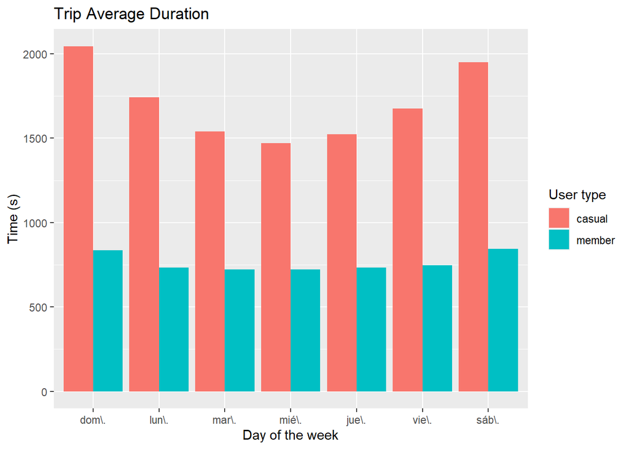

```r
all_trips_v2 %>%
  mutate(weekday = wday(started_at, label = TRUE)) %>%
  group_by(member_casual, weekday) %>%
  summarise(number_of_rides = n()
            ,average_duration = mean(ride_length)) %>%
  arrange(member_casual, weekday)  %>%
  ggplot(aes(x = weekday, y = average_duration , fill = member_casual)) +
  geom_col(position = "dodge") + ggtitle("Trip Average Duration") + xlab("Day of the week") + ylab("Time (s)") + labs(fill="User type")
```